# Django app

V rámci projektu si pre poriadok vytvoríme separátnu aplikáciu `blog`.

Zapnite si virtuálne prostredie (venv) a presuňte sa v termináli do zložky `django_project/`.

Windows / macOS / Linux

```
$ python manage.py startapp blog
```

Vytvorí sa nová zložka `blog` a obsahuje ďalšie súbory. Zložka s našim projektom by mala vyzerať takto:

```
django_project
├── blog
│   ├── admin.py
│   ├── apps.py
│   ├── __init__.py
│   ├── migrations
│   │   └── __init__.py
│   ├── models.py
│   ├── tests.py
│   └── views.py
├── db.sqlite3
├── manage.py
├── pyladies_project
│   ├── asgi.py
│   ├── __init__.py
│   ├── settings.py
│   ├── urls.py
│   └── wsgi.py
└── requirements.txt
```

Vytvorenú aplikáciu `blog` pridáme do zoznamu `INSTALLED_APPS` v nastavení projektu `django_project/pyladies_project/settings.py` aby Django vedelo, že ju má použiť. Bude to vyzerať takto:

```
INSTALLED_APPS = [
    'django.contrib.admin',
    'django.contrib.auth',
    'django.contrib.contenttypes',
    'django.contrib.sessions',
    'django.contrib.messages',
    'django.contrib.staticfiles',
    'blog',
]
```

# Čo je Django?

- vytvorené ako interný projekt pre vývoj webových aplikácií v Lawrence Journal-World v rokoch 2003-2005 (prvý oficiálny release 2008)
- populárny python framework využívaný pre web development
- Django sa drží princípu MVC (Model-View-Controller), ktorý je štandardom pre vývoj webových aplikácií
- opensource, zdarma, má veľkú a aktívnu komunitu, dobrú dokumentáciu a rozličné možnosti rozšírenia (väčšina je zdarma)

Pre MVC princíp má Django vlastnú konvenciu MVT (Model-View-Template)

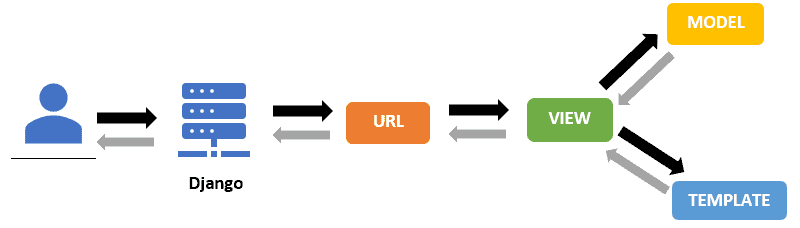

Model - je vrstva určená k správe dát, predstavuje prepojenie celej architektúry s databázou; 1 model = 1 tabuľka v databáze.

View - je určené pre definovanie cekovej logiky datového toku. Zároveň zaisťuje odosielanie response (odpovede) danému užívateľovi.

Template - prezentačná vrstva ktorá sa stará o interakcie s užívateľom.

## Vytvorenie modelu pre príspevok na blogu

Model v Django je špeciálny druh objektu – je uložený v databáze. Databáza je súbor údajov.

Je to miesto kam budete ukladať informácie o užívateľoch, príspevky na blogu atď.

Model v databáze si môžete predstaviť ako tabuľku so stĺpcami a riadkami.

Aké atribúty a metódy by taký príspevok na blogu mohol mať?

```python
from django.conf import settings
from django.db import models
from django.utils import timezone


class Post(models.Model):
    author = models.ForeignKey(settings.AUTH_USER_MODEL, on_delete=models.CASCADE)
    title = models.CharField(max_length=200)
    text = models.TextField()
    created_date = models.DateTimeField(default=timezone.now)
    published_date = models.DateTimeField(blank=True, null=True)

    def publish(self):
        self.published_date = timezone.now()
        self.save()

    def __str__(self):
        return self.title
```

Pre vytvorenie tabuľky pre model v databáze je potrebné Django najskôr informovať o tom, že máme nejaké zmeny.

```python
$ python manage.py makemigrations blog
Migrations for 'blog':
  blog/migrations/0001_initial.py
    - Create model Post
```

Django vytvorilo súbor s migráciou ktorý chceme aplikovať do našej databáze.

```python
$ python manage.py migrate blog
Operations to perform:
  Apply all migrations: blog
Running migrations:
  Applying blog.0001_initial... OK
```

## Django Admin

Pre tvorbu, editáciu a zmazanie príspevkov využijeme Django admin (administrátorské rozhranie).

Otvoríme si súbor `blog/admin.py` a vložíme do neho:

```python
from django.contrib import admin
from .models import Post

admin.site.register(Post)
```

```python
$ python manage.py runserver
```

V prehliadači si otvoríme stránku `http://127.0.0.1:8000/admin/`.

Pre prihlásenie do rozhrania je potrebné vytvoriť si tzv. superuser-a, účet ktorý má v administrátorskom rozhraní plnú kontrolu.

Otvoríme si nový terminál (webserver nám musí stále bežať) v ktorom máme zapnutý venv a zadáme do neho:

```python
$ python manage.py createsuperuser
```

Zadáme údaje (heslo sa pri písaní nezobrazuje). Napr.:

```python
Username: alby
Email address: alby@example.com
Password:
Password (again):
Superuser created successfully.
```

Vrátime sa späť do prehliadača a údaje použijeme pre prihlásenie. Mali by sme sa po prihlásení dostať do administrátorského rozhrania, kde si vytvoríme nejaké nové príspevky.

## Django ORM (Objects-Relational-Mapper)

Umožňuje interakcie s databázou.

Otvoríme si Django konzolu

```python
$ python manage.py shell
```

Naimportujeme si náš model

```python
>>> from blog.models import Post
```

Výpis všetkých objektov:

```python
>>> Post.objects.all()
```

V konzoli si môžeme tvoriť nové objekty:

```python
>>> Post.objects.create(author=me, title='Sample title', text='Test')
```

Premenná `me` je neznáma a aby sme mohli vytvoriť `Post`, potrebujeme do poľa `author` predať objekt užívateľa.

Naimportujeme si Django model `User`:

```python
>>> from django.contrib.auth.models import User
```

Vypíšeme si existujúcich užívateľov.

```python
>>> User.objects.all()
```

Do premennej si uložíme svojho užívateľa:

```python
>>> me = User.objects.get(username='alby')
```

Vyskúšame vytvoriť znova:

```python
>>> Post.objects.create(author=me, title='Sample title', text='Test')
```

Skúsime si vyfiltrovať publikované:

```python
>>> from django.utils import timezone
>>> Post.objects.filter(published_date__lte=timezone.now())
```

Zatiaľ nemáme žiadne publikované články, môžeme nejaké publikovať pomocou metódy `publish()`:

```python
>>> post = Post.objects.get(title="Sample title")
>>> post.publish()
```

Vo vyfiltrovaných publikovaných príspevkoch teraz uvidíme náš príspevok:

```python
>>> Post.objects.filter(published_date__lte=timezone.now())
```

Objekty si môžeme zoradiť:

```python
>>> Post.objects.order_by('created_date')

>>> Post.objects.order_by('-created_date')
```

Metódy môžeme reťaziť:

```python
>>> Post.objects.filter(published_date__lte=timezone.now()).order_by('published_date')
```

Konzolu opustíme:

```python
>>> exit()
```

## Django URLs

Django využíva URLconf (URL configuration), ktorý obsahuje zoznam schémat na základe ktorých sa párujú Python triedy (tzv. views) s URL cestami.

Pozrieme sa na URLs nášho projektu `pyladies_project/urls.py`.

`path('admin/', admin.site.urls)` znamená, že pre všetky URL, ktoré začínajú na `admin/` Django nájde korešpondujúce view. V tomto prípade to zahŕňa veľké množstvo admin podstránok, ktoré sú zabalené do jedného súboru z modulu admin.

Aby sme do URLs nášho projektu zahrnuli aj schémata z našej aplikácie blog, pridáme ich do `urlpatters`:

```python
urlpatterns = [
    path('admin/', admin.site.urls),
    path('', include('blog.urls')),
]
```

Toto zaistí, že pri všetkých requestoch smerujúcich na `http://127.0.0.1:8000/` sa Django pozrie do `blog.urls` a hľadá tam ďalšie inštrukcie.

Vytvorenie vlastných URL pre aplikáciu blog v súbore `blog/urls.py`:

```python
from django.urls import path
from . import views

urlpatterns = [
    path('', views.PostListView.as_view(), name='post_list'),
]
```

## Django views

Do súboru `blog/views.py` si pridáme novú view.

```python
from django.shortcuts import render
from django.views.generic import TemplateView


class PostListView(TemplateView):
    template_name = 'blog/post_list.html'

    def get(self, request):
        return render(request, self.template_name, {})
```

## HTML šablóny v Django

HTML šablóna je súbor v jazyku HTML, ktorý sa dá prepoužiť pre zobrazenie rôznych informácií v konzistentnom formáte.

HTML (HyperText Markup Language) je kód interpretovaný prehliadačom pre zobrazenie webovej stránky užívateľovi.

Je zložený z tzv. tagov každý začínajúci na `<` a končiaci na `>`, ktoré reprezentujú elementy.

Pre vytvorenie prvej šablóny si v zložke blog vytvoríme následovné podzložky:

```python
blog
└───templates
    └───blog
```

A v zložke `blog/templates/blog` si vytvoríme súbor `post_list.html` a znovu si načítame našu domovskú stránku.

Pridáme nejaký kód do `post_list.html` a znova načítame domovskú stránku

```python
<!DOCTYPE html>
<html>
	<head>
		<title>Alby's blog</title>
	</head>
	<body>
	    <p>Hi there!</p>
	    <p>It works!</p>
	</body>
</html>
```

Rozšírime html

```python
<!DOCTYPE html>
<html>
    <head>
        <title>Django Girls blog</title>
    </head>
    <body>
        <header>
            <h1><a href="/">Django Girls Blog</a></h1>
        </header>

        <article>
            <time>published: 14.06.2014, 12:14</time>
            <h2><a href="">My first post</a></h2>
            <p>Aenean eu leo quam. Pellentesque ornare sem lacinia quam venenatis vestibulum. Donec id elit non mi porta gravida at eget metus. Fusce dapibus, tellus ac cursus commodo, tortor mauris condimentum nibh, ut fermentum massa justo sit amet risus.</p>
        </article>

        <article>
            <time>published: 14.06.2014, 12:14</time>
            <h2><a href="">My second post</a></h2>
            <p>Aenean eu leo quam. Pellentesque ornare sem lacinia quam venenatis vestibulum. Donec id elit non mi porta gravida at eget metus. Fusce dapibus, tellus ac cursus commodo, tortor mauris condimentum nibh, ut f.</p>
        </article>
    </body>
</html>
```

## Dynamické dáta v šablónach

Pre zobrazenie nami vytvorených publikovaných príspevkov (modely uložené do databáze) v našej šablóne využijeme `PostListView()` v súbore `views.py`.

```python
from django.shortcuts import render
from django.views.generic import TemplateView


class PostListView(TemplateView):
    template_name = 'blog/post_list.html'

    def get(self, request):
        return render(request, self.template_name, {})
```

Naimportujeme si model `Post()` a modul `timezone`

```python
from django.utils import timezone
from .models import Post
```

Vytvoríme si Queryset (zoznam objektov z databáze, umožňuje čítať, radiť či filtrovať dáta z databáze) a uložíme si ho do premennej

```python
posts = Post.objects.filter(published_date__lte=timezone.now()).order_by('published_date')
```

Premennú pridáme do posledného parametru funkcie `render()`, ktorá sa nazýva `context` a nesie v sebe informácie, ktoré chceme šablóne poskytnúť

```python
from django.shortcuts import render
from django.views.generic import TemplateView
from django.utils import timezone
from .models import Post

class PostListView(TemplateView):
    template_name = 'blog/post_list.html'

    def get(self, request):
        posts = Post.objects.filter(published_date__lte=timezone.now()).order_by('published_date')
        return render(request, self.template_name, {'posts': posts})
```

Pridáme dáta do šablóny

```python
{% for post in posts %}
    {{ post }}
{% endfor %}
```

```python
<header>
    <h1><a href="/">Django Girls Blog</a></h1>
</header>

{% for post in posts %}
    <article>
        <time>published: {{ post.published_date }}</time>
        <h2><a href="">{{ post.title }}</a></h2>
        <p>{{ post.text|linebreaksbr }}</p>
    </article>
{% endfor %}
```